# Assignment 1

Nguyen Quoc Dinh, 300550781

2023-03-31

**Question 1** Classify the following variables as categorical or numerical and further classify as logical, nominal, ordinal, binary, continuous or discrete. ALSO give the R class AND the R type that corresponds to each.

Answer:

1. Air temperature: numerical/continuous
2. Length of time spent looking for work: numerical/continuous
3. Success in winning an election: categorical/logical
4. Response to the question How often do you avoid news stories about climate change? (scale 1-6, 1=never, 2=rarely, …, 6=always): categorical/ordinal
5. Number of attempts at a goal before scoring: numerical/integer

**Question 2**

Answer:

1. Display the values of a and z.

```r
a<- c(3,4,1)
print(a)
```

```
## [1] 3 4 1
```

```r
z<- array(c(-1,1,7,0,6,1), dim= c(3,2))
print(z)
```

```
##      [,1] [,2]
## [1,]   -1    0
## [2,]    1    6
## [3,]    7    1
```

2. Write R code that will show the maximum value of a

```r
max(a)
```

```
## [1] 4
```

3. Make a 3×2 array which has two copies of the vector a side by side, and store it as the object d. Print out the value of d.

```r
d<-array(
  rep(a,times=2),  # 2 copies
  dim=c(3,2)       # a 3x2 array
)
d
```

```
##      [,1] [,2]
## [1,]    3    3
## [2,]    4    4
## [3,]    1    1
```

4. Write R code to print out the elements of a that are larger than the corresponding elements of the second column of z.

```r
a[a>z[,2]]
```

```
## [1] 3
```

5. Print the sum of the product of z and d.

```r
sum(prod(z),prod(d))
```

```
## [1] 144
```

6. Explain why the product of a and z - which have differing dimensions - is the same as the product of d and z.

```r
a*z
```

```
##      [,1] [,2]
## [1,]   -3    0
## [2,]    4   24
## [3,]    7    1
```

```r
d*z
```

```
##      [,1] [,2]
## [1,]   -3    0
## [2,]    4   24
## [3,]    7    1
```

Explanation: the product of two vectors (differt dimensions and/or different shape) follow the rule that the shorter vector is recycled to match the dimension and shape of the longer one.

**Question 3**

1. Give the code of your function

```r
convert.temperature<- function(x, from = "F"){
  # more entrance condition
  if(is.numeric(x) == FALSE){
    stop("Temperature must be numeric")
  }

  if(from=="F"){
    return ((x-32)*5/9)
  }else if(from=="C"){
    return ((x*9/5)+32)
  }
  else{
    stop("Invalid input specification")
  }
}
```

2. Demonstrate your function with the tests convert.temperature(20) and convert.temperature(20, from=“C”)

```r
# testing
convert.temperature(20)
```

```
## [1] -6.666667
```

```r
convert.temperature(20,"C")
```

```
## [1] 68
```

3. Confirm that the function works on vectors by evaluating the Fahrenheit temperature on the vector of temperatures 0:100 Celcius.

```r
convert.temperature(0:100, "C")
```

```
##   [1]  32.0  33.8  35.6  37.4  39.2  41.0  42.8  44.6  46.4  48.2  50.0  51.8
##  [13]  53.6  55.4  57.2  59.0  60.8  62.6  64.4  66.2  68.0  69.8  71.6  73.4
##  [25]  75.2  77.0  78.8  80.6  82.4  84.2  86.0  87.8  89.6  91.4  93.2  95.0
##  [37]  96.8  98.6 100.4 102.2 104.0 105.8 107.6 109.4 111.2 113.0 114.8 116.6
##  [49] 118.4 120.2 122.0 123.8 125.6 127.4 129.2 131.0 132.8 134.6 136.4 138.2
##  [61] 140.0 141.8 143.6 145.4 147.2 149.0 150.8 152.6 154.4 156.2 158.0 159.8
##  [73] 161.6 163.4 165.2 167.0 168.8 170.6 172.4 174.2 176.0 177.8 179.6 181.4
##  [85] 183.2 185.0 186.8 188.6 190.4 192.2 194.0 195.8 197.6 199.4 201.2 203.0
##  [97] 204.8 206.6 208.4 210.2 212.0
```

4. The coldest physical temperature is -273.15 Celcius. What is this on the Fahrenheit scale?

```r
convert.temperature(-273.15,"C")
```

```
## [1] -459.67
```

5. Modify your function so that it returns NA for any temperature below -273.15 Celcius, printing a warning as it does so. Give the R code of the modified function

```r
convert.temperature<- function(x, from = "F"){
  if(!is.numeric(x)){
    stop("Temperature must be numeric")
  }
  if(from != "C" & from != "F"){
    stop("Invalid input specification")
  }

  result <- c()
  n <- length(x)

  for(i in 1:n){
    result[i]<- NA
    if(from == "C") {
      if(x[i] < -273.15)
        next
      else {
        result[i]<-x[i]*(9/5)+32
      }
    } else {
      result[i]<- (x[i]-32)*(5/9)
      if(result[i]< -273.15)
        next
    }
  }



  if (any(is.na(result))){
        warning("Please change the value. It must not be below -273.15 Celcius")
  }
  return(result)
}
```

6. Test your modified function on the vector of Celcius temperatures c(100,0,-100,-200,-300) to see that it has the correct behaviour.

```r
convert.temperature(c(100,0,-100,-200,-300),"C")
```

```
## Warning in convert.temperature(c(100, 0, -100, -200, -300), "C"): Please change
## the value. It must not be below -273.15 Celcius
```

```
## [1]  212   32 -148 -328   NA
```

**Question 4**

1. Write R code to read the file starsearch.csv into an object called star. Note that when reading the file you will need to skip the first two lines of the file (find out how to skip lines by consulting the appropriate help file in R)

```r
star<- read.csv("starsearch.csv", skip=2)
head(star)
```

```
##     Month Keanu.Reeves...Worldwide. star.trek...Worldwide.
## 1 2004-01                         5                     28
## 2 2004-02                         5                     26
## 3 2004-03                         4                     28
## 4 2004-04                         5                     26
## 5 2004-05                         5                     28
## 6 2004-06                         4                     25
```

b and c. Write R code to determine the number of rows and columns of star

```r
paste("The number of rows of star is :", nrow(star))
```

```
## [1] "The number of rows of star is : 231"
```

```r
paste("The number of columns of star is :", ncol(star))
```

```
## [1] "The number of columns of star is : 3"
```

4. Convert the first column of star into date format. It only has year and month specified (e.g. 2004-01 for January 2004), and to convert to a date we need to tell it which day of the month. We’ll assume each date is the first of the relevant month: which means we want to change 2004-01 to 2004-01-01. Append -01 to each entry in the Month column using the paste() function, and then you can make the date conversion on the result.

```r
star$Month<-paste(star$Month,sep="", "-01" )

star$Month<-as.Date(star$Month,format=("%Y-%m-%d"))

head(star)
```

```
##        Month Keanu.Reeves...Worldwide. star.trek...Worldwide.
## 1 2004-01-01                         5                     28
## 2 2004-02-01                         5                     26
## 3 2004-03-01                         4                     28
## 4 2004-04-01                         5                     26
## 5 2004-05-01                         5                     28
## 6 2004-06-01                         4                     25
```

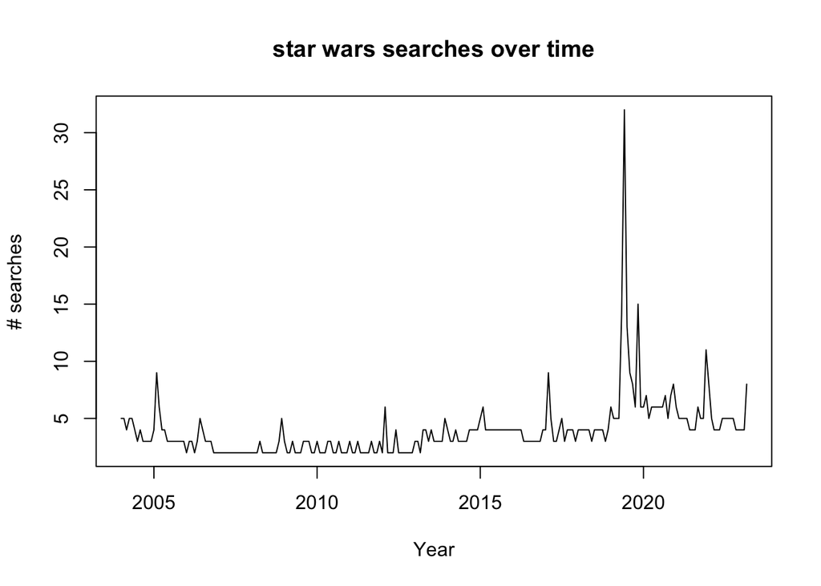

```r
plot(
  x = star[,1],
  y = star[,2],
  type="line",
  xlab = "Year",
  ylab = "# searches",
  main = "star wars searches over time"
)
```

```r
months <- star$Month[star[,3] > star[,2]]

print("Months where there were more ‘star trek’ searches than ‘star wars’ searches: ")
```

```
## [1] "Months where there were more ‘star trek’ searches than ‘star wars’ searches: "
```

```r
print(format(months,format = "%B - %Y"))
```

```
##   [1] "January - 2004"   "February - 2004"  "March - 2004"
##   [4] "April - 2004"     "May - 2004"       "June - 2004"
##   [7] "July - 2004"      "August - 2004"    "September - 2004"
##  [10] "October - 2004"   "November - 2004"  "December - 2004"
##  [13] "January - 2005"   "February - 2005"  "March - 2005"
##  [16] "April - 2005"     "May - 2005"       "June - 2005"
##  [19] "July - 2005"      "August - 2005"    "September - 2005"
##  [22] "October - 2005"   "November - 2005"  "December - 2005"
##  [25] "January - 2006"   "February - 2006"  "March - 2006"
##  [28] "April - 2006"     "May - 2006"       "June - 2006"
##  [31] "July - 2006"      "August - 2006"    "September - 2006"
##  [34] "October - 2006"   "November - 2006"  "December - 2006"
##  [37] "January - 2007"   "February - 2007"  "March - 2007"
##  [40] "April - 2007"     "May - 2007"       "June - 2007"
##  [43] "July - 2007"      "August - 2007"    "September - 2007"
```

[output cut: 61 more lines]

**Question 5** Assuming x and y are vectors of length 3, explain the difference between the actions of the following four statements

x = y : assign x with y’s values, vice versa. They are pointing to the same location on memory.

x == y : compare x and y (TRUE/FALSE)

x <- y : assign the values of y to x and changing x will not affect y.

x < (-y) : compare x whether less than (-y)

**Question 6**

1. Draw a histogram of student heights

```r
library(MASS)

head(survey)
```

```
##      Sex Wr.Hnd NW.Hnd W.Hnd    Fold Pulse    Clap Exer Smoke Height      M.I
## 1 Female   18.5   18.0 Right  R on L    92    Left Some Never 173.00   Metric
## 2   Male   19.5   20.5  Left  R on L   104    Left None Regul 177.80 Imperial
## 3   Male   18.0   13.3 Right  L on R    87 Neither None Occas     NA     <NA>
## 4   Male   18.8   18.9 Right  R on L    NA Neither None Never 160.00   Metric
## 5   Male   20.0   20.0 Right Neither    35   Right Some Never 165.00   Metric
## 6 Female   18.0   17.7 Right  L on R    64   Right Some Never 172.72 Imperial
##      Age
## 1 18.250
## 2 17.583
## 3 16.917
## 4 20.333
## 5 23.667
## 6 21.000
```

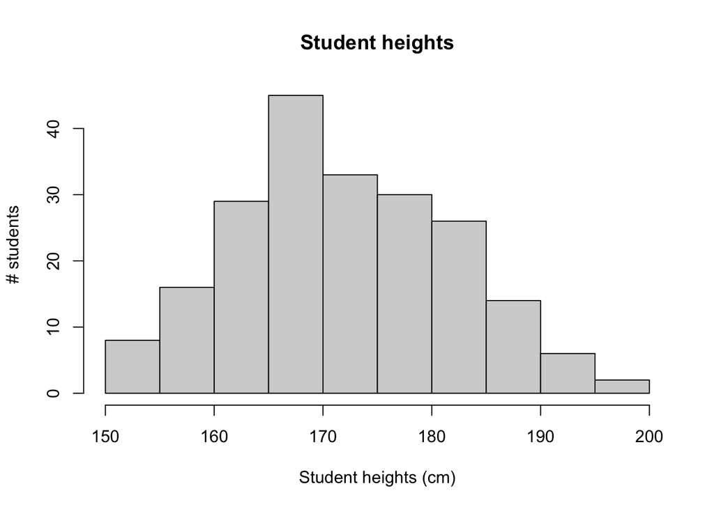

```r
hist(
  survey$Height,
  xlab = "Student heights (cm)",
  ylab = "# students",
  main = "Student heights")
```

2. Draw side by side boxplots of heights - one for each of the different ways the students fold their arms. Make the fill colour of the boxes dark red.

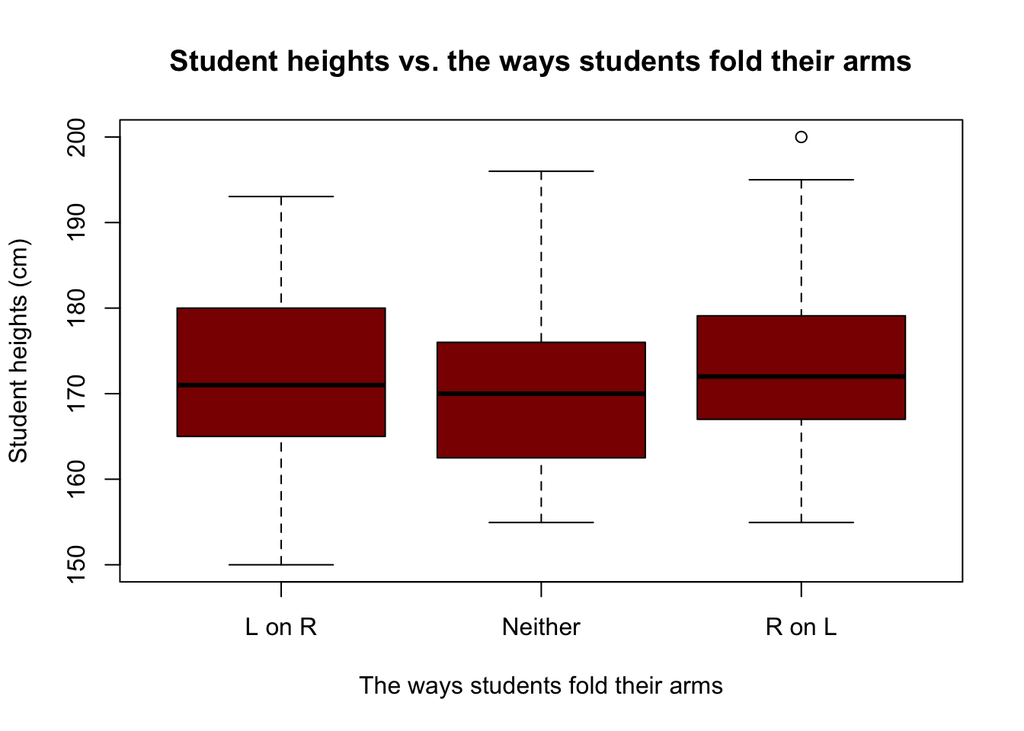

```r
boxplot(
  split(survey$Height,survey$Fold),
  xlab = "The ways students fold their arms",
  ylab = "Student heights (cm)",
  main = "Student heights vs. the ways students fold their arms",
  col = "darkred" )
```

3. Draw a scatterplot of pulse rate (on the vertical axis) against student height (on the horizontal axis)

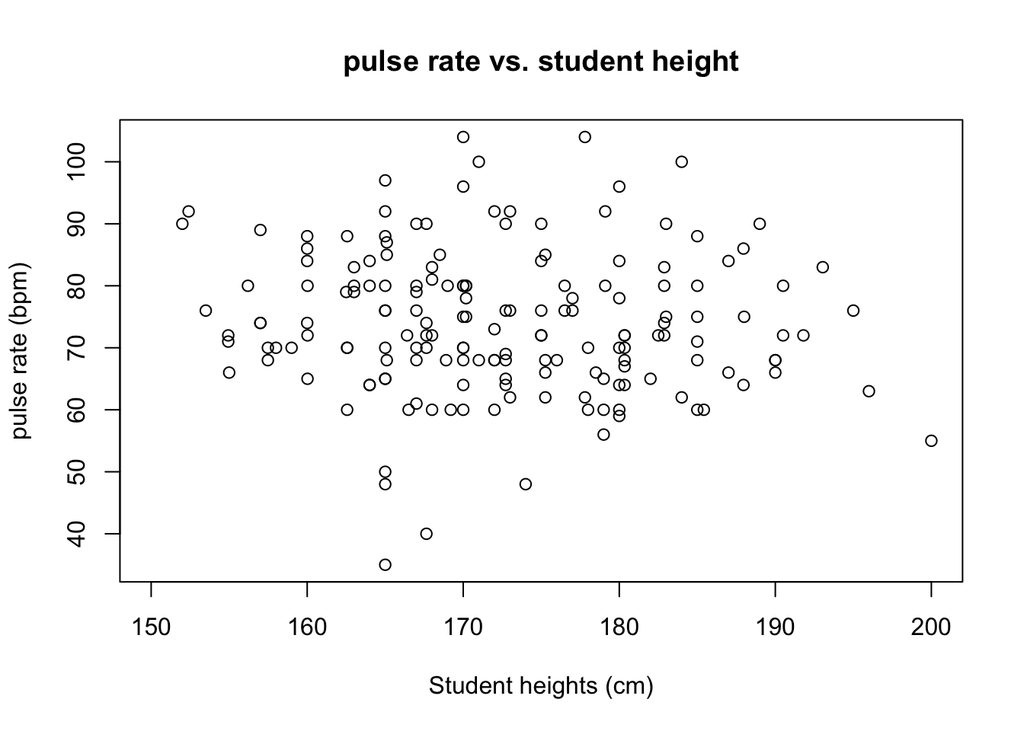

```r
plot(
  survey$Height,
  survey$Pulse,
  xlab = "Student heights (cm)",
  ylab = "pulse rate (bpm)",
  main = "pulse rate vs. student height"
)
```

4. Draw side by side barplots of the counts of people categorised by how much they exercise and whether they smoke.

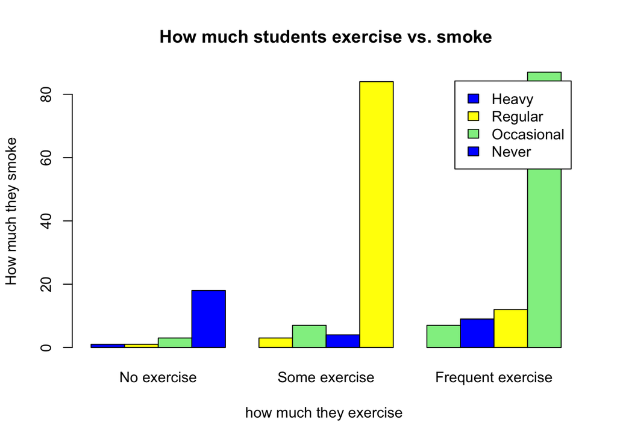

```r
survey$Exer <- factor(
  survey$Exer,
  levels = c("None","Some","Freq"),
  labels = c("No exercise","Some exercise","Frequent exercise")
  )
survey$Smoke <- factor(
  survey$Smoke,
  levels = c("Heavy", "Regul","Occas", "Never"),
  labels = c("Heavy","Regular","Occasional","Never")
  )


barplot(
  table(survey$Smoke,survey$Exer),
  beside = TRUE,
  xlab = "how much they exercise ",
  ylab = "How much they smoke",
  main = "How much students exercise vs. smoke",
  legend=TRUE,
  col=c("blue","yellow","lightgreen")
)
```

**Question 7**

a.Use R to find out what day of the week it was when ChatGPT was first released.

```r
#ChatGPT was initially released on November 30, 2022.
gpt_release <- as.Date("November 30, 2022", format = "%B %d, %Y")

paste("The day of the week it was when ChatGPT was first released: ", weekdays(gpt_release))
```

```
## [1] "The day of the week it was when ChatGPT was first released:  Wednesday"
```

2. What date and time (to the nearest hour) was it in New York when the Titanic set sail from Southampton in 1912? Give R code to make this calculation between time zones.

```r
# The Titanic set sail from Southampton on April 10, 1912 at 12:00 pm local time.
Titanic_Southampton <- as.POSIXct("April 10, 1912 at 12", format ="%B %d, %Y at %H", tz = "Europe/London")

Titanic_NewYork<- format(
  Titanic_Southampton,
  format ="%H:%M %B %d in %Y",
  tz = "US/Eastern"
)

paste(
  "When the Titanic set sail from Southampton in 1912 at 12:00 pm local time, in New York was",
  Titanic_NewYork
)
```

```
## [1] "When the Titanic set sail from Southampton in 1912 at 12:00 pm local time, in New York was 07:00 April 10 in 1912"
```